# Take-home exercise3

This article is to discuss the financial health of the city of Engagement, Ohio USA (VAST Challenge 2022).

Li Minqi https://www.linkedin.com/in/minqi-li/ (School of Computing and Information System)https://example.com/spacelysprokets  
2022-05-21

# 1. Overview

## 1.1 Introduction

In this take-home exercise, we will discuss the financial health of the city of Engagement and identify which businesses appear to be more prosperous or more struggling over the period covered by the data set.

The data used in this exercise is from VAST Challenge 2022, and processed by RStudio. It is assumed that the volunteer participants are representative of the city’s population.

## 1.2 Design challenges

### Challenge 1: How to joint different tables

VAST Challenge 2022 provided a large number of data files. Upon review, out of total files, eleven files can used in this study and they all have similar primary keys, such as building ID and participant ID. To have an overview of all these data files, jointing tables and data cleaning are required to be performed in R for reproducibility.

### Challenge 4: Raw Data File is too big to upload

The financial journal file used to derive income data is 80.7 MB, larger than the 50 MB size limit set by GitHub. Therefore, the raw data cannot be pushed to GitHub repository directly.

This can be resolved by preparing the dataframe for visualization, and then saving it in RDS format. The raw data is not pushed or commited while only the saved RDS file is referenced for visualization, and pushed to GitHub repository

# 2. Data Preparation

## 2.1 R packages installation

The following code chunk installs the required R packages and loads them onto RStudio environment.

```r
packages = c('tidyverse', 'knitr', 'ggdist', 'scales', 'grid', 'gridExtra','formattable', 'patchwork', 'shiny','ggridges','gganimate','gifski','RColorBrewer','zoo','plotly','reprex','gifski','png')

for(p in packages){
  if(!require(p,character.only= T)){
    install.packages(p)
  }
  library(p,character.only=T)
}
```

## 2.2 Import Datasets

This article will use the dataset provided by [**VAST Challenge 2022**](https://vast-challenge.github.io/2022/). The code chunk below import data from the folder into R by using [`read_csv()`](https://readr.tidyverse.org/reference/read_delim.html) of [**readr**](https://readr.tidyverse.org/) and save it as an tibble data frame. In order to compare, we convert all timestemp from files into date formate.

```r
participants <- read_csv('Data/Participants.csv')
financial <- read_csv('Data/FinancialJournal.csv') %>%
  mutate(Dates = as.Date(timestamp,format="%m/%d/%Y"))
Apartments <- read_csv('Data/Apartments.csv')
Employers <- read_csv('Data/Employers.csv')
Pubs <- read_csv('Data/Pubs.csv')
Restaurants <- read_csv('Data/Restaurants.csv')
Schools <- read_csv('Data/Schools.csv')
```

## 2.3 Data Wrangling

### Expenditure

```r
Food <- financial %>%
  filter(category == 'Food') %>%
  select(Dates,amount,participantId) %>%
  group_by(Dates) %>%
  summarise(Daily_food = abs(sum(amount)), group_size= length(participantId))
```

```r
Education <- financial %>%
  filter(category == 'Education') %>%
  select(Dates,amount,participantId) %>%
  group_by(Dates) %>%
  summarise(Daily_Education = abs(sum(amount)),group_size= length(participantId))
```

```r
Recreation <- financial %>%
  filter(category == 'Recreation') %>%
  select(Dates,amount,participantId) %>%
  group_by(Dates) %>%
  summarise(Daily_Recreation = abs(sum(amount)),group_size= length(participantId))
```

```r
Shelter <- financial %>%
  filter(category == 'Shelter') %>%
  select(Dates,amount,participantId) %>%
  group_by(Dates) %>%
  summarise(Daily_Shelter = abs(sum(amount)),group_size= length(participantId))
```

## 2.4 Save as and Read RDS

Dataframes of all expenditure are saved and read in RDS format to avoid uploading large files to Git.

```r
saveRDS(Food, 'data/Food.rds')
Food <- readRDS('data/Food.rds')

saveRDS(Education, 'data/Education.rds')
Education <- readRDS('data/Education.rds')

saveRDS(Recreation, 'data/Recreation.rds')
Recreation <- readRDS('data/Recreation.rds')

saveRDS(Shelter, 'data/Shelter.rds')
Shelter <- readRDS('data/Shelter.rds')
```

# 3. Visualization and Insights

### Movement of residents spending on food

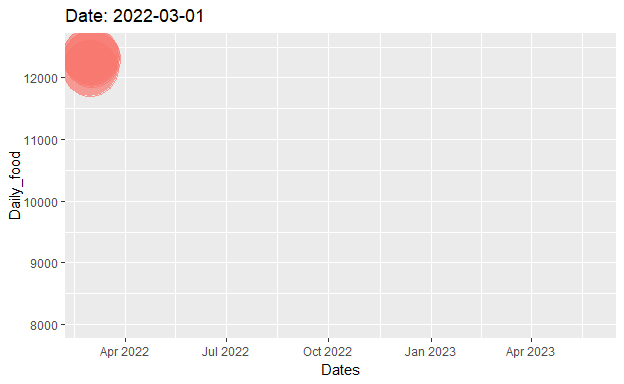

```r
p1<-ggplot(Food, aes(x = Dates, y = Daily_food,
                      size = group_size,
                      colour = 'red')) +
  geom_point(alpha = 0.7,
             show.legend = FALSE) +
  scale_size(range = c(2, 20)) +
  labs(title = 'Date: {frame_time}',
       x = 'Dates',
       y = 'Daily_food')+ ylim(8000,12500)+ transition_time(Dates) +
  ease_aes('linear')
animate(p1, duration = 20)
```

### Movement of residents spending on Education

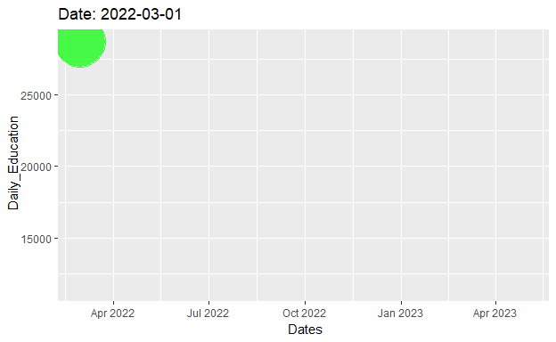

```r
p2<- ggplot(Education, aes(x = Dates, y = Daily_Education,
                      size = group_size)) +
  geom_point(alpha = 0.7,
             show.legend = FALSE, colour = 'Green') +
  scale_size(range = c(2, 20)) +
  labs(title = 'Date: {frame_time}',
       x = ' Dates',
       y = ' Daily_Education') + transition_time(Dates) +
  ease_aes('linear')

animate(p2, duration = 20)
```

### Movement of residents spending on Shelter

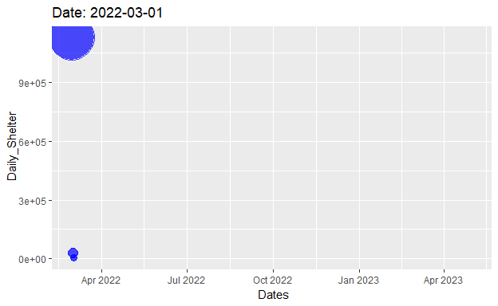

```r
p3<- ggplot(Shelter, aes(x = Dates, y = Daily_Shelter,
                      size = group_size)) +
  geom_point(alpha = 0.7,
             show.legend = FALSE, colour = 'Blue') +
  scale_size(range = c(2, 20)) +
  labs(title = 'Date: {frame_time}',
       x = ' Dates',
       y = ' Daily_Shelter') + transition_time(Dates) +
  ease_aes('linear')

animate(p3, duration = 20)
```

# 4. Conclusion

**Education is the most struggling business.**

The the animation of people daily expenditure on education, we can infer that less people spend money in education and the amount of money people spend on education is also getting much lower.

**People spend a bit less on food, but industry still performs well.**

**There is a significant improvement in real estate market.**

According to the research, people spent less on rental in between of April 2022 and May 2022, but the market recovered rapidly in June 2022. It performed well in both revenue and customer size.